# Lab06

Duan Xuheng

2022-09-21

# STATS 769 Lab 06

## The Data Set

The data source for this lab is from UCI Machine Learning Repository. We are going to the use a subset of the Bank Marketing data set (bank-full), the description of which can be found here: https://archive.ics.uci.edu/ml/datasets/bank+marketing.

## Task

```r
bank = read.csv("bank-subset.csv", strings=TRUE)
X = model.matrix(y ~ ., data=bank)[,-1]        # design matrix, without intercept
i = 1:1000
train = data.frame(X[i,], y=bank$y[i])         # training set
test = data.frame(X[-i,], y=bank$y[-i])        # test set

library(MASS)
library(e1071)
library(class)
library(parallel)
```

### Introduction

1. In your own words, describe briefly the data and the practical problem that is associated with the data.

```r
print("The data relate to the direct marketing activities (via telephone) of Portuguese banking institutions. The categorical objective is to predict whether a customer will subscribe to a fixed deposit (variable Y)")
```

```
## [1] "The data relate to the direct marketing activities (via telephone) of Portuguese banking institutions. The categorical objective is to predict whether a customer will subscribe to a fixed deposit (variable Y)"
```

```r
print("Does bank telemarketing really bring in revenue? Is income higher than expenditure?")
```

```
## [1] "Does bank telemarketing really bring in revenue? Is income higher than expenditure?"
```

2. Use the linear discrimant analysis to predict the class labels. Produce the confusion matrix and compute the misclassification rate, for both the training and test sets. Train:

```r
(r2 = lda(y ~ ., data=train))
(p2 = predict(r2, newdata=train))
yhat2 = p2$class
```

```r
table(train$y, yhat2)
```

```
##      yhat2
##        no yes
##   no  863  29
##   yes  63  45
```

```r
(A = 1- mean(train$y == yhat2))
```

```
## [1] 0.092
```

Test

```r
(r2b = lda(y ~ ., data=train))
(p2b = predict(r2b, newdata=test))
yhat2b = p2b$class
```

```r
table(test$y, yhat2b)
```

```
##      yhat2b
##         no  yes
##   no  3430  137
##   yes  258  175
```

```r
(A = 1- mean(test$y == yhat2b))
```

```
## [1] 0.09875
```

3.Use the Naive Bayes method to predict the class labels. Produce the confusion matrix and compute the misclassification rate, for both the training and test sets.

```r
rm(list=ls())
bank = read.csv("bank-subset.csv", strings=TRUE)
X = model.matrix(y ~ ., data=bank)[,-1]        # design matrix, without intercept
i = 1:1000
train = data.frame(X[i,], y=bank$y[i])         # training set
test = data.frame(X[-i,], y=bank$y[-i])        # test set

library(MASS)
library(e1071)
library(class)
library(parallel)
```

```r
(r3a = naiveBayes(y ~ ., data=train))
(yhat3a = predict(r3a, newdata=train))
```

```r
table(train$y, yhat3a)
```

```
##      yhat3a
##        no yes
##   no  721 171
##   yes  34  74
```

```r
(A = 1 - mean(train$y == yhat3a))
```

```
## [1] 0.205
```

```r
#(yhat = predict(r, newdata=train, type="raw"))
```

```r
(r3b = naiveBayes(y ~ ., data=train))
(yhat3b = predict(r3b, newdata=test))
```

```r
table(test$y, yhat3b)
```

```
##      yhat3b
##         no  yes
##   no  2887  680
##   yes  173  260
```

```r
(A = 1 - mean(test$y == yhat3b))
```

```
## [1] 0.21325
```

```r
#(yhat = predict(r, newdata=train, type="raw"))
```

4.Use the K-nearest-neighbour (KNN) method to predict the class labels, with K=1,5, respectively. Produce the confusion matrix and compute the misclassification rates, for both the training and test sets. k=1 train

```r
rm(list=ls())
bank = read.csv("bank-subset.csv", strings=TRUE)
X = model.matrix(y ~ ., data=bank)[,-1]        # design matrix, without intercept
i = 1:1000
train = data.frame(X[i,], y=bank$y[i])         # training set
test = data.frame(X[-i,], y=bank$y[-i])        # test set

library(MASS)
library(e1071)
library(class)
library(parallel)
```

```r
yhat4a1 = knn(train=train[,1:42], test=train[,1:42], cl=train[,43], k=1)
table(train[,43], yhat4a1)
```

```
##      yhat4a1
##        no yes
##   no  892   0
##   yes   0 108
```

```r
(A = 1 - mean(train$y == yhat4a1))
```

```
## [1] 0
```

k=1 test

```r
yhat4a2 = knn(train=test[,1:42], test=test[,1:42], cl=test[,43], k=1)
table(test[,43], yhat4a2)
```

```
##      yhat4a2
##         no  yes
##   no  3567    0
##   yes    0  433
```

```r
(A = 1 - mean(test$y == yhat4a2))
```

```
## [1] 0
```

```r
yhat4b1 = knn(train=train[,1:42], test=train[,1:42], cl=train[,43], k=5)
table(train[,43], yhat4b1)
```

```
##      yhat4b1
##        no yes
##   no  882  10
##   yes  87  21
```

```r
(A = 1 - mean(train$y == yhat4b1))
```

```
## [1] 0.097
```

```r
yhat4b2 = knn(train=test[,1:42], test=test[,1:42], cl=test[,43], k=5)
table(test[,43], yhat4b2)
```

```
##      yhat4b2
##         no  yes
##   no  3512   55
##   yes  287  146
```

```r
(A = 1 - mean(test$y == yhat4b2))
```

```
## [1] 0.0855
```

5.Use the K-nearest-neighbour (KNN) method to predict the class labels, with K=1,2,…,30, respectively. Compute the misclassification rates, for both the training and test sets. Show the two curves for the misclassifcation rate versus K in one graph.

```r
rm(list=ls())
bank = read.csv("bank-subset.csv", strings=TRUE)
X = model.matrix(y ~ ., data=bank)[,-1]        # design matrix, without intercept
i = 1:1000
train = data.frame(X[i,], y=bank$y[i])         # training set
test = data.frame(X[-i,], y=bank$y[-i])        # test set

library(MASS)
library(e1071)
library(class)
library(parallel)
```

```r
list1 = list()
list2 = list()
for (i in 1:30){
  yhat5a = knn(train=train[,1:42], test=train[,1:42], cl=train[,43], k=i)
  mr1 = 1-(A = mean(train$y == yhat5a))
  print(mr1)
  yhat5b = knn(train=test[,1:42], test=test[,1:42], cl=test[,43], k=i)
  mr2 = 1-(A = mean(test$y == yhat5b))
  print(mr2)
  list1[i] = mr1
  list2[i] = mr2
}
```

```
## [1] 0
## [1] 0
## [1] 0.069
## [1] 0.078
## [1] 0.076
## [1] 0.076
## [1] 0.087
## [1] 0.083
## [1] 0.097
## [1] 0.0855
## [1] 0.098
## [1] 0.091
## [1] 0.103
## [1] 0.09075
## [1] 0.105
```

[output cut: 45 more lines]

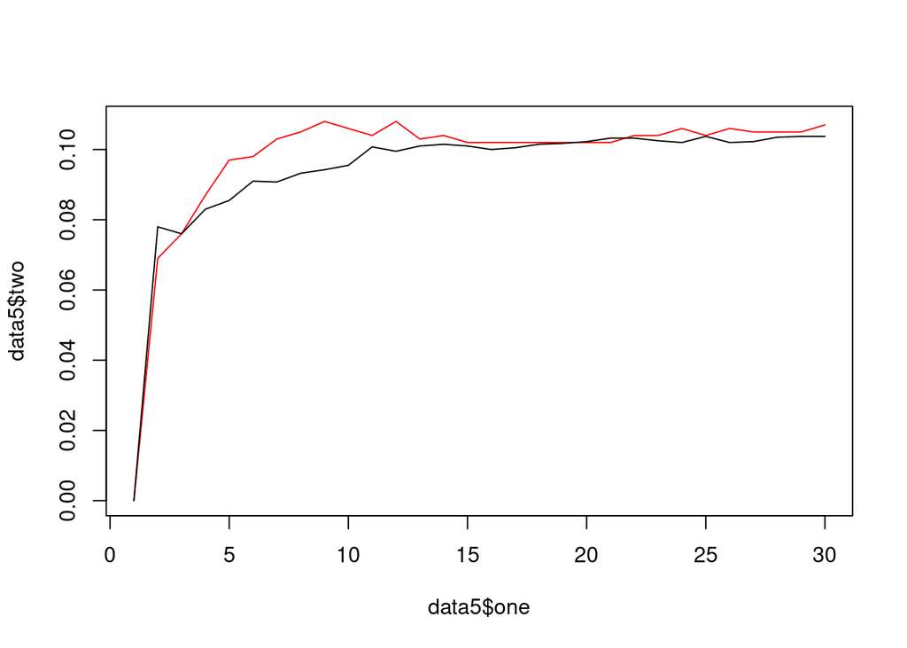

```r
data5 = data.frame(one=c(1:30), two=unlist(list1), three=unlist(list2))
plot(x=data5$one,y=data5$two,type = 'l', col = 'red')
lines(data5$three)
```

6. Use 10-fold cross-validation, with 20 repetitions, to find an appropriate value for K in KNN from the training data only. Explain why you have used the technique of same subsamples.

```r
rm(list=ls())
bank = read.csv("bank-subset.csv", strings=TRUE)
X = model.matrix(y ~ ., data=bank)[,-1]        # design matrix, without intercept
i = 1:1000
train = data.frame(X[i,], y=bank$y[i])         # training set
test = data.frame(X[-i,], y=bank$y[-i])        # test set

library(MASS)
library(e1071)
library(class)
library(parallel)
```

```r
K = 43
R = 20                                   # number of repetitions
M = 10                                   # M-fold CV
pe = matrix(nrow=R*M, ncol=K)            # pre-allocate space
(n = nrow(train))
```

```
## [1] 1000
```

```r
## returns indies of a test test in CV
# i -- which fold
# n -- sample size
# K -- total number of folds

test.set = function(i, n, K=10) {
  index = c(0, round(1:(K-1)*n/K), n)
  (index[i]+1):index[i+1]
}

set.seed(769)                    # set a random seed

for(i in 1:R) {                  # for each repetition
  ind = sample(n)
  for(j in 1:M) {                # for each fold
    index = ind[test.set(j, n, M)]
    test1 = train[index,]
    train1 = train[-index,]
    for(k in 1:K) {              # for each k nearest neighbours (method)
      yhat = knn(train=train1[,1:42], test=test1[,1:42], cl=train1[,43], k=k) # prediction for test data
      pe[M*(i-1)+j,k] = mean(yhat != test1[,43])  # misclassification rate for test data
    }
  }
}

head(pe)
```

```
##      [,1] [,2] [,3] [,4] [,5] [,6] [,7] [,8] [,9] [,10] [,11] [,12] [,13] [,14]
## [1,] 0.13 0.16 0.11 0.09 0.09 0.09 0.08 0.07 0.07  0.06  0.06  0.06  0.06  0.06
## [2,] 0.11 0.11 0.12 0.09 0.10 0.12 0.10 0.10 0.10  0.09  0.09  0.09  0.09  0.09
## [3,] 0.17 0.15 0.13 0.13 0.10 0.09 0.10 0.10 0.10  0.10  0.10  0.10  0.10  0.10
## [4,] 0.17 0.17 0.16 0.15 0.13 0.15 0.12 0.13 0.13  0.13  0.13  0.13  0.13  0.13
## [5,] 0.14 0.15 0.11 0.11 0.11 0.12 0.13 0.12 0.13  0.12  0.12  0.12  0.12  0.11
## [6,] 0.18 0.14 0.17 0.19 0.16 0.16 0.17 0.16 0.16  0.16  0.16  0.16  0.16  0.16
##      [,15] [,16] [,17] [,18] [,19] [,20] [,21] [,22] [,23] [,24] [,25] [,26]
## [1,]  0.06  0.06  0.06  0.06  0.06  0.06  0.06  0.07  0.07  0.08  0.07  0.07
## [2,]  0.09  0.09  0.09  0.09  0.09  0.09  0.09  0.09  0.09  0.09  0.09  0.09
## [3,]  0.10  0.10  0.10  0.10  0.10  0.10  0.10  0.10  0.10  0.10  0.10  0.10
## [4,]  0.14  0.14  0.14  0.14  0.14  0.14  0.14  0.14  0.14  0.14  0.14  0.14
## [5,]  0.11  0.11  0.11  0.12  0.12  0.12  0.12  0.12  0.12  0.12  0.12  0.13
## [6,]  0.16  0.16  0.16  0.16  0.16  0.16  0.16  0.16  0.16  0.16  0.16  0.16
##      [,27] [,28] [,29] [,30] [,31] [,32] [,33] [,34] [,35] [,36] [,37] [,38]
## [1,]  0.08  0.08  0.07  0.07  0.07  0.08  0.08  0.08  0.08  0.08  0.08  0.08
## [2,]  0.09  0.10  0.10  0.10  0.10  0.10  0.10  0.10  0.10  0.10  0.10  0.10
## [3,]  0.10  0.10  0.10  0.10  0.10  0.10  0.10  0.10  0.09  0.10  0.09  0.09
## [4,]  0.14  0.14  0.13  0.13  0.13  0.13  0.13  0.13  0.13  0.13  0.13  0.13
## [5,]  0.13  0.13  0.13  0.13  0.13  0.13  0.13  0.13  0.13  0.13  0.13  0.13
## [6,]  0.16  0.16  0.16  0.16  0.16  0.16  0.16  0.16  0.16  0.16  0.16  0.16
##      [,39] [,40] [,41] [,42] [,43]
## [1,]  0.08  0.08  0.08  0.08  0.08
## [2,]  0.10  0.10  0.10  0.10  0.10
## [3,]  0.09  0.09  0.09  0.09  0.09
## [4,]  0.13  0.13  0.13  0.13  0.13
## [5,]  0.13  0.13  0.13  0.13  0.13
## [6,]  0.16  0.16  0.16  0.16  0.16
```

```r
(pe3 = colMeans(pe))
```

```
##  [1] 0.14255 0.14495 0.12280 0.12755 0.11470 0.11565 0.11290 0.11260 0.11015
## [10] 0.10870 0.10570 0.10485 0.10355 0.10315 0.10245 0.10295 0.10315 0.10425
## [19] 0.10430 0.10500 0.10505 0.10605 0.10590 0.10590 0.10625 0.10635 0.10725
## [28] 0.10765 0.10815 0.10825 0.10805 0.10800 0.10785 0.10785 0.10820 0.10790
## [37] 0.10795 0.10795 0.10790 0.10795 0.10800 0.10800 0.10800
```

```r
(k.optimal = which.min(pe3))
```

```
## [1] 15
```

```r
#(yhat = knn.cv(train1[,1:42], train1[,43], k = 10))
```

7. Use the Jackknifing technique (with a 90% for training and 10% for testing) to find an appropriate value for K in KNN from the training data only. Use R = 200 as the number of repetitions.

```r
rm(list=ls())
bank = read.csv("bank-subset.csv", strings=TRUE)
X = model.matrix(y ~ ., data=bank)[,-1]        # design matrix, without intercept
i = 1:1000
train = data.frame(X[i,], y=bank$y[i])         # training set
test = data.frame(X[-i,], y=bank$y[-i])        # test set

library(MASS)
library(e1071)
library(class)
library(parallel)
```

```r
(n = nrow(train))
```

```
## [1] 1000
```

```r
(n2 = round(n * 0.10))
```

```
## [1] 100
```

```r
K = 30                                # largest K-value in comparison
R = 200                               # number of repetitions
pe = matrix(nrow=R, ncol=K)           # pre-allocate space for prediction errors
dim(pe)
```

```
## [1] 200  30
```

```r
library(class)
set.seed(769)           # set a random seed

for(j in 1:K) {
  for(i in 1:R) {
    index = sample(n, n2)
    test1 = train[index,]
    train1 = train[-index,]
    yhat = knn(train=train1[,1:42], test=test1[,1:42], cl=train1[,43], k=j) # prediction for test data
    pe[i,j] = mean(yhat != test1[,43])  # misclassification rate for test data
  }
}
head(pe)
```

```
##      [,1] [,2] [,3] [,4] [,5] [,6] [,7] [,8] [,9] [,10] [,11] [,12] [,13] [,14]
## [1,] 0.13 0.17 0.11 0.13 0.11 0.12 0.09 0.13 0.09  0.17  0.13  0.09  0.09  0.11
## [2,] 0.09 0.13 0.14 0.10 0.17 0.17 0.10 0.12 0.13  0.13  0.07  0.08  0.11  0.11
## [3,] 0.19 0.14 0.13 0.13 0.06 0.13 0.07 0.13 0.10  0.11  0.10  0.05  0.18  0.13
## [4,] 0.20 0.16 0.11 0.11 0.08 0.09 0.10 0.13 0.08  0.11  0.09  0.11  0.08  0.06
## [5,] 0.12 0.16 0.16 0.12 0.11 0.13 0.10 0.09 0.09  0.12  0.09  0.10  0.07  0.07
## [6,] 0.16 0.15 0.11 0.12 0.14 0.10 0.10 0.15 0.17  0.19  0.14  0.14  0.16  0.09
##      [,15] [,16] [,17] [,18] [,19] [,20] [,21] [,22] [,23] [,24] [,25] [,26]
## [1,]  0.13  0.14  0.09  0.14  0.15  0.08  0.12  0.08  0.09  0.16  0.15  0.11
## [2,]  0.13  0.11  0.10  0.11  0.13  0.06  0.15  0.09  0.13  0.08  0.08  0.14
## [3,]  0.10  0.10  0.11  0.14  0.17  0.09  0.09  0.09  0.12  0.11  0.08  0.11
## [4,]  0.12  0.11  0.08  0.11  0.05  0.12  0.15  0.13  0.09  0.09  0.14  0.11
## [5,]  0.08  0.10  0.11  0.13  0.06  0.10  0.08  0.08  0.11  0.16  0.09  0.08
## [6,]  0.11  0.09  0.12  0.15  0.14  0.08  0.07  0.13  0.18  0.16  0.14  0.09
##      [,27] [,28] [,29] [,30]
## [1,]  0.16  0.10  0.05  0.09
## [2,]  0.16  0.10  0.16  0.07
## [3,]  0.11  0.12  0.12  0.12
## [4,]  0.14  0.12  0.11  0.11
## [5,]  0.11  0.12  0.10  0.07
## [6,]  0.09  0.09  0.09  0.08
```

```r
(pe1 = colMeans(pe))
```

```
##  [1] 0.14280 0.14770 0.12510 0.12535 0.11390 0.11875 0.11310 0.11485 0.10840
## [10] 0.10950 0.10535 0.10375 0.10515 0.10095 0.10265 0.10480 0.10365 0.10440
## [19] 0.10820 0.10335 0.10375 0.10240 0.10250 0.10550 0.10420 0.10950 0.10905
## [28] 0.10925 0.10920 0.10595
```

```r
(k.optimal = which.min(pe1))
```

```
## [1] 14
```

8.Rewrite/reorganise your code so that each repetition can be carried out independently. Perform the Jackknifing selection of the K-value from the training set using parallel computing, with function mclapply().

Compare the timings, when 1, 5, 10 or 20 cores are used (so you have to do this on a VM).

```r
rm(list=ls())
bank = read.csv("bank-subset.csv", strings=TRUE)
X = model.matrix(y ~ ., data=bank)[,-1]        # design matrix, without intercept
i = 1:1000
train = data.frame(X[i,], y=bank$y[i])         # training set
test = data.frame(X[-i,], y=bank$y[-i])        # test set

library(MASS)
library(e1071)
library(class)
library(parallel)
```

```r
(n = nrow(train))
```

```
## [1] 1000
```

```r
(n2 = round(n * 0.10))
```

```
## [1] 100
```

```r
K = 30                                # largest K-value in comparison
R = 200                               # number of repetitions
pe = matrix(nrow=R, ncol=K)           # pre-allocate space for prediction errors
dim(pe)
```

```
## [1] 200  30
```

```r
library(class)
set.seed(769)

system.time(pe2 <- lapply(c(1:30), function(j){
  for(i in 1:R) {
    index = sample(n, n2)
    test1 = train[index,]
    train1 = train[-index,]
    yhat = knn(train=train1[,1:42], test=test1[,1:42], cl=train1[,43], k=j) # prediction for test data
    pe[i,j] = mean(yhat != test1[,43])  # misclassification rate for test data
  }
  return(mean(pe[,j]))
}))
```

```
##    user  system elapsed
##  33.011   0.000  33.020
```

```r
system.time(pe2 <- mclapply(c(1:30), function(j){
  for(i in 1:R) {
    index = sample(n, n2)
    test1 = train[index,]
    train1 = train[-index,]
    yhat = knn(train=train1[,1:42], test=test1[,1:42], cl=train1[,43], k=j) # prediction for test data
    pe[i,j] = mean(yhat != test1[,43])  # misclassification rate for test data
  }
  return(mean(pe[,j]))
},mc.cores=5))
```

```
##    user  system elapsed
##  30.572   0.384   8.282
```

```r
system.time(pe2 <- mclapply(c(1:30), function(j){
  for(i in 1:R) {
    index = sample(n, n2)
    test1 = train[index,]
    train1 = train[-index,]
    yhat = knn(train=train1[,1:42], test=test1[,1:42], cl=train1[,43], k=j) # prediction for test data
    pe[i,j] = mean(yhat != test1[,43])  # misclassification rate for test data
  }
  return(mean(pe[,j]))
},mc.cores=10))
```

```
##    user  system elapsed
##  36.125   0.760   4.421
```

```r
rm(pe2)
system.time(pe2 <- mclapply(c(1:30), function(j){
  for(i in 1:R) {
    index = sample(n, n2)
    test1 = train[index,]
    train1 = train[-index,]
    yhat = knn(train=train1[,1:42], test=test1[,1:42], cl=train1[,43], k=j) # prediction for test data
    pe[i,j] = mean(yhat != test1[,43])  # misclassification rate for test data
  }
  return(mean(pe[,j]))
},mc.cores=20))
```

```
##    user  system elapsed
##  41.769   1.427   3.290
```

```r
(k.optimal = which.min(pe2))
```

```
## [1] 14
```

[Not required as part of this assignment, you might want to study how parallel computing can be applied to cross-validation.]

```r
rm(list=ls())
bank = read.csv("bank-subset.csv", strings=TRUE)
X = model.matrix(y ~ ., data=bank)[,-1]        # design matrix, without intercept
i = 1:1000
train = data.frame(X[i,], y=bank$y[i])         # training set
test = data.frame(X[-i,], y=bank$y[-i])        # test set

library(MASS)
library(e1071)
library(class)
library(parallel)
```